# Okesola_Moses_Olusola_Business_Statistics_E_news_Express_Project (1)

**Problem Description**

**Business Context**

The advent of e-news, or electronic news, portals has offered us a great opportunity to quickly get updates on the day-to-day events occurring globally. The information on these portals is retrieved electronically from online databases, processed using a variety of software, and then transmitted to the users.

There are multiple advantages of transmitting new electronically, like faster access to the content and the ability to utilize different technologies such as audio, graphics, video, and other interactive elements that are either not being used or aren’t common yet in traditional newspapers.

E-news Express, an online news portal, aims to expand its business by acquiring new subscribers. With every visitor to the website taking certain actions based on their interest, the company plans to analyze these actions to understand user interests and determine how to drive better engagement.

The executives at E-news Express are of the opinion that there has been a decline in new monthly subscribers compared to the past year because the current webpage is not designed well enough in terms of the outline & recommended content to keep customers engaged long enough to make a decision to subscribe.

Companies often analyze user responses to two variants of a product to decide which of the two variants is more effective. This experimental technique, known as A/B testing, is used to determine whether a new feature attracts users based on a chosen metric.

**Objective**

The design team of the company has researched and created a new landing page that has a new outline & more relevant content shown compared to the old page. In order to test the effectiveness of the new landing page in gathering new subscribers, the Data Science team conducted an experiment by randomly selecting 100 users and dividing them equally into two groups.

The existing landing page was served to the first group (control group) and the new landing page to the second group (treatment group). Data regarding the interaction of users in both groups with the two versions of the landing page was collected. Being a data scientist in E-news Express, you have been asked to explore the data and perform a statistical analysis **(at a significance level of 5%)** to determine the effectiveness of the new landing page in gathering new subscribers for the news portal by answering the following questions:

**1.Do the users spend more time on the new landing page than on the existing landing page?**

**2.Is the conversion rate (the proportion of users who visit the landing page and get converted) for the new page greater than the conversion rate for the old page?**

**3.Does the converted status depend on the preferred language?**

**4.Is the time spent on the new page the same for the different language users?**

**Data Dictionary**

The data contains information regarding the interaction of users in both groups with the two versions of the landing page.

**1.user_id -** Unique user ID of the person visiting the website.

**2.group -** Whether the user belongs to the first group (control) or the second group (treatment).

**3.landing_page** - Whether the landing page is new or old.

**4.time_spent_on_the_page** - Time (in minutes) spent by the user on the landing page.

**5.converted-** Whether the user gets converted to a subscriber of the news portal or not.

**6.language_preferred-** Language chosen by the user to view the landing page.

**Importing necessary libraries**

```python
# Libraries that help with reading and manipulating data
import numpy as np
import pandas as pd
```

```python
# Libraries that help with data visualization
import matplotlib.pyplot as plt
import seaborn as sns
```

```python
# Library for scientific computing
import scipy.stats as stats

# Import required statistical functions
from scipy.stats import binom
from scipy.stats import norm
```

```python
# Command to tell python to display the graphs or plots
%matplotlib inline
```

**Loading the ENews Exress Dataset**

```python
E_News_data = pd.read_csv('/content/drive/MyDrive/abtest.csv')
```

**Overview of the E-News Dataset**

```python
# The first five rows of the dataset- This is to check if the dataset is properly loaded
E_News_data.head()
```

|  | user_id | group | landing_page | time_spent_on_the_page | converted | language_preferred |
| --- | --- | --- | --- | --- | --- | --- |
| 0 | 546592 | control | old | 3.48 | no | Spanish |
| 1 | 546468 | treatment | new | 7.13 | yes | English |
| 2 | 546462 | treatment | new | 4.40 | no | Spanish |
| 3 | 546567 | control | old | 3.02 | no | French |
| 4 | 546459 | treatment | new | 4.75 | yes | Spanish |

- The dataset contains each user' s unique identifier refers to as user id, visiting the E-News Express website.
- There are two groups namely control, and treament in the dataset.
- The page (landing page) which is either old or new visited by a user is recorded in the dataset.
- The time (in minutes) spent by users on a type of landing page is contained in the dataset.
- The conversion status (yes or no), who become subscriber or not of each user that visited a type of landing page is stated.
- The preferred language of each customer when visited any of the two landing pages is also contained in the dataset.

```python
# Display the last five row of the dataset
E_News_data.tail()
```

|  | user_id | group | landing_page | time_spent_on_the_page | converted | language_preferred |
| --- | --- | --- | --- | --- | --- | --- |
| 95 | 546446 | treatment | new | 5.15 | no | Spanish |
| 96 | 546544 | control | old | 6.52 | yes | English |
| 97 | 546472 | treatment | new | 7.07 | yes | Spanish |
| 98 | 546481 | treatment | new | 6.20 | yes | Spanish |
| 99 | 546483 | treatment | new | 5.86 | yes | English |

**The number of rows and columns in the dataset**

```python
# Understanding the shape of the dataset
E_News_data.shape
```

```
(100, 6)
```

There are one hundred rows and six columns.

```python
# extract the list of columns in the dataset
E_News_data. columns
```

```
Index(['user_id', 'group', 'landing_page', 'time_spent_on_the_page',
       'converted', 'language_preferred'],
      dtype='object')
```

There are six columns namely:'user_id', 'group', 'landing_page', 'time_spent_on_the_page','converted', 'language_preferred'.

**The datatype of each column in the dataset**

```python
# Checking the data types of the columns for the dataset
E_News_data. info()
```

```
<class 'pandas.core.frame.DataFrame'>
RangeIndex: 100 entries, 0 to 99
Data columns (total 6 columns):
 #   Column                  Non-Null Count  Dtype
---  ------                  --------------  -----
 0   user_id                 100 non-null    int64
 1   group                   100 non-null    object
 2   landing_page            100 non-null    object
 3   time_spent_on_the_page  100 non-null    float64
 4   converted               100 non-null    object
 5   language_preferred      100 non-null    object
dtypes: float64(1), int64(1), object(4)
memory usage: 4.8+ KB
```

- There are two numerical columns and four object columns in the dataset.
- We observed that user_id is read as an integer type column instead of unique identifier.
- All the columns have their entries complete.

```python
 # Get the list of columns with categorical data types
categorical_cols = E_News_data.select_dtypes(include=['object']).columns
categorical_cols
```

```
Index(['group', 'landing_page', 'converted', 'language_preferred'], dtype='object')
```

**Checking for missing values in the data**

```python
# Checking for missing values in the data
E_News_data. isnull().sum()
```

```
user_id                   0
group                     0
landing_page              0
time_spent_on_the_page    0
converted                 0
language_preferred        0
dtype: int64
```

There are no missing values in the E-News Express dataset.

**Statistical summary of the dataset**

```python
# Getting the statistical summary for the dataset
E_News_data.describe()
```

|  | user_id | time_spent_on_the_page |
| --- | --- | --- |
| count | 100.000000 | 100.000000 |
| mean | 546517.000000 | 5.377800 |
| std | 52.295779 | 2.378166 |
| min | 546443.000000 | 0.190000 |
| 25% | 546467.750000 | 3.880000 |
| 50% | 546492.500000 | 5.415000 |
| 75% | 546567.250000 | 7.022500 |
| max | 546592.000000 | 10.710000 |

- The average time (in minutes) spent by a user on a landing page is 5.38.
- The standard deviation or spread from the average time (in minutes) spent by a user on a landing page is 2.38.
- The minimum time in minutes) spent by a user on a landing page is 0.19 or 11.4 seconds.
- The maximum time (in minutes) spent by a user on a landing page is 10.71.
- The range of time (in minutes) spent by a user on a landing page is from 0.19(minimum) to 10.71 (maximum).
- The median of the time (in minutes) spent by users on a landing page which is 50 percentiles is 5.42.

**Drop user id since it is a unique identifier that wont affect our analysis, and create a copy of the dataset**

```python
# Create a copy of the DataFrame
E_News_datacopy = E_News_data.copy()

# Drop a column from the copy of the DataFrame
column_to_drop = 'user_id'
E_News_datacopy.drop(column_to_drop, axis=1, inplace=True)

# Print the original DataFrame and the modified copy
print("Original DataFrame:")
print(E_News_data. head())

print("\nDataFrame with Column Dropped:")
print(E_News_datacopy.head())
```

```
Original DataFrame:
   user_id      group landing_page  time_spent_on_the_page converted  \
0   546592    control          old                    3.48        no
1   546468  treatment          new                    7.13       yes
2   546462  treatment          new                    4.40        no
3   546567    control          old                    3.02        no
4   546459  treatment          new                    4.75       yes

  language_preferred
0            Spanish
1            English
2            Spanish
3             French
4            Spanish

DataFrame with Column Dropped:
       group landing_page  time_spent_on_the_page converted language_preferred
0    control          old                    3.48        no            Spanish
1  treatment          new                    7.13       yes            English
2  treatment          new                    4.40        no            Spanish
3    control          old                    3.02        no             French
4  treatment          new                    4.75       yes            Spanish
```

```python
# Checking the data types of the columns for the E_News_data_copy dataset
E_News_datacopy. info()
```

```
<class 'pandas.core.frame.DataFrame'>
RangeIndex: 100 entries, 0 to 99
Data columns (total 5 columns):
 #   Column                  Non-Null Count  Dtype
---  ------                  --------------  -----
 0   group                   100 non-null    object
 1   landing_page            100 non-null    object
 2   time_spent_on_the_page  100 non-null    float64
 3   converted               100 non-null    object
 4   language_preferred      100 non-null    object
dtypes: float64(1), object(4)
memory usage: 4.0+ KB
```

- There is one numerical variable,namely, 'time_spent_on *the* page'.
- There are four categorical variables, namely, 'group', 'landing_page', 'converted', and 'language_preferred'.
- There is no missing value.

**Statistical summary of the E_News_data_copy dataset**

```python
E_News_datacopy. describe()
```

|  | time_spent_on_the_page |
| --- | --- |
| count | 100.000000 |
| mean | 5.377800 |
| std | 2.378166 |
| min | 0.190000 |
| 25% | 3.880000 |
| 50% | 5.415000 |
| 75% | 7.022500 |
| max | 10.710000 |

**Identify categorical variables**

```python
 # Get the list of columns with categorical data types
categorical_cols = E_News_datacopy.select_dtypes(include=['object']).columns

# Print the list of categorical columns
print("Categorical Variables:")
print(categorical_cols)
```

```
Categorical Variables:
Index(['group', 'landing_page', 'converted', 'language_preferred'], dtype='object')
```

There are four categorical columns namely: 'group', 'landing_page', 'converted', and 'language_preferred'.

**Give statistical summary of the categorical variables in the dataset**

```python
 # find the count of each unique value in the 'group' column of E-News dataset
E_News_datacopy['group'].value_counts()
```

```
control      50
treatment    50
Name: group, dtype: int64
```

- There are 50 users in 'control' group that visit the E-News Express website.
- There are 50 users in 'treatment' group that visit the E-News Express website.

```python
# find the count of each unique value in the 'language_preferred' column of E-News dataset
E_News_datacopy['language_preferred'].value_counts()
```

```
Spanish    34
French     34
English    32
Name: language_preferred, dtype: int64
```

- 34 users of E-News Express website preferred Spanish when visited landing page.
- 34 users of E-News Express website preferred French when visited landing page.
- 32 users of E-News Express website preferred English when visited landing page.

```python
# find the count of each unique value in the 'converted' column of E-News dataset
E_News_datacopy['converted'].value_counts()
```

```
yes    54
no     46
Name: converted, dtype: int64
```

- 54 users that visited the landing page of E-News Express website become subscribers of the new portal.
- 46 users that visited the landing page of E-News Express website declined subscription of the new portal.

```python
# find the count of each unique value in the 'landing_page' column of E-News dataset
E_News_datacopy['landing_page'].value_counts()
```

```
old    50
new    50
Name: landing_page, dtype: int64
```

- There are 50 users that visit the 'old' landing page of E-News Express online news portal.
- There are 50 users that visit the 'new' landing page of E-News Express online news portal.

**Statistical summary for each categorical variable**

```python
# Specify the categorical variables
categorical_cols = ['group', 'landing_page', 'converted', 'language_preferred']
# Provide a statistical summary for each categorical variable
for col in categorical_cols:
    print("Statistical summary for {col}:")
    print(E_News_datacopy[col].describe())
    print()
```

[output not shown]

**Check any missing values in the E_News_datacopy**

```python
# check for missing value in the E_News_datacopy dataset
E_News_datacopy. isnull().sum()
```

```
group                     0
landing_page              0
time_spent_on_the_page    0
converted                 0
language_preferred        0
dtype: int64
```

There is no missing value in all the column variables.

**Check the original E-News Express dataset for duplicates**

```python
# Check for duplicates in the columns of the E-News dataset
duplicates = E_News_data[E_News_data.duplicated()]

# Print the duplicate colums if any
if not duplicates.empty:
    print("Duplicate Columns:")
    print(duplicates)
else:
    print("No duplicate columns found.")
```

```
No duplicate columns found.
```

There is no duplicate in all the columns of the dataset.

**Exploratory Data Analysis of E-News Express Dataset**

**Univariate Analysis: Analysis of one variable for statistical summary**

**Numerical variable : Time spent on landing page**

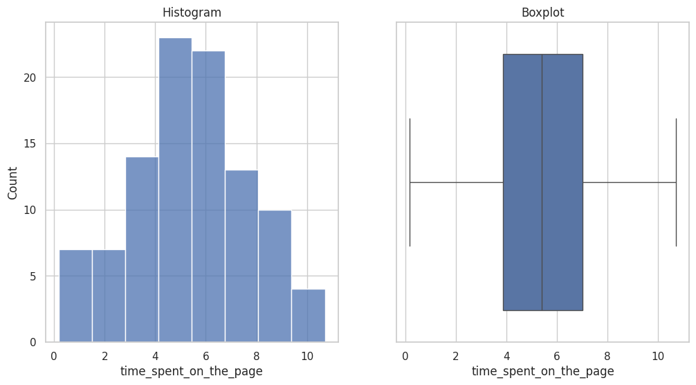

```python
# Create histogram and box plots for Time spent on landing page

# Create a figure and set of subplots
fig, axs = plt.subplots(ncols=2, figsize=(12, 6))

# Plotting histogram in the first subplot on the left
sns.histplot(data=E_News_data, x='time_spent_on_the_page', ax=axs[0])
axs[0].set_title('Histogram')

# Plotting boxplot in the second subplot on the right
sns.boxplot(data=E_News_data, x='time_spent_on_the_page', ax=axs[1])
axs[1].set_title('Boxplot')

plt.show()
```

1.The maximum time spent when a user visited the landing page in E-News Express website is slightly above 10.6 minutes , and the minimum time spent when visited the landing page in E-News Express website is slightly above 0 minute.

2.More users visited the landing page between 4 and above 6 minutes, while at between 9.5 and higher than 10.6 minutes, the website has the least visiting users.

3.The distribution is symmetric.

4.The 25th percentile is close to 4 minutes and the 75th percentile is largely above 7 minutes.

5.The median 'Time spent on landing page' is almost 5.5 minutes.

6.There are no outliers in the distribution of 'Time spent on the loading page'.

**Univariate Analysis : Categorical variables**

**Group**

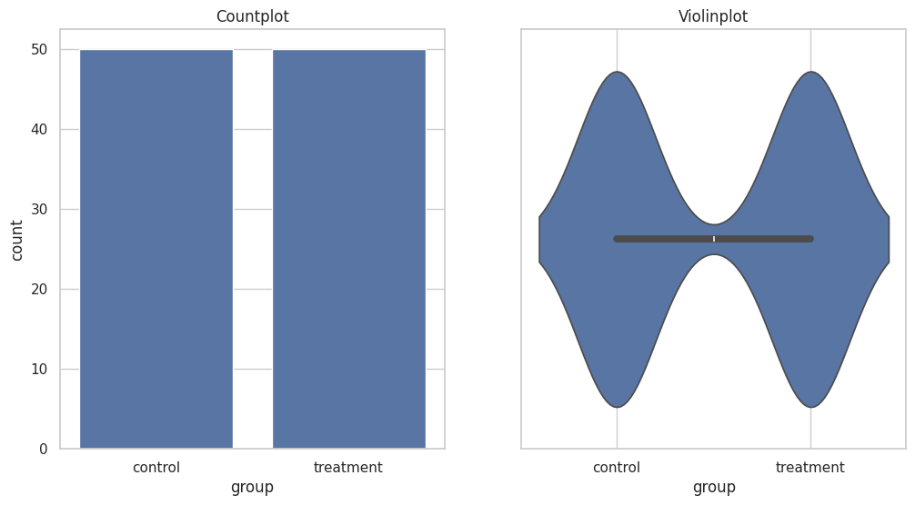

```python
# Create count and violin plots for the 'Group' variable in the dataset

# Create a figure and set of subplots
fig, axs = plt.subplots(ncols=2, figsize=(12, 6))

E_News_datacopy['group'].value_counts()
sns.countplot(data=E_News_datacopy,x='group', ax=axs[0])
axs[0].set_title('Countplot')

sns.violinplot(data=E_News_datacopy,x='group',ax=axs[1])
axs[1].set_title('Violinplot')
plt.show()
```

- The number of users in both 'control' group is the same as the number in 'treatment' group.
- The distribution is symmetric between the 'control' group and the 'treatment' group.
- There are equal number of data points between the 'control' group and the 'treatment' group.
- The median divides the distribution into two equal parts.

**Landing Page**

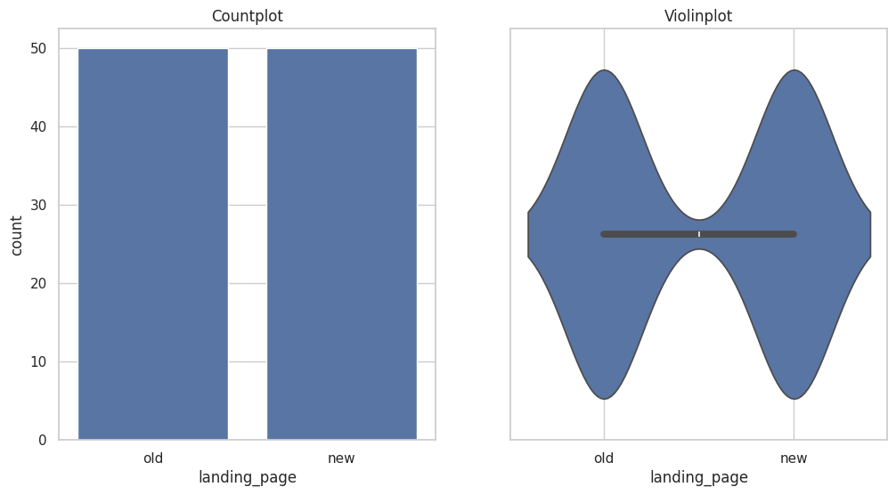

```python
# Create count and violin plots for the 'Landing page' variable in the dataset

# Create a figure and set of subplots
fig, axs = plt.subplots(ncols=2, figsize=(12, 6))

E_News_datacopy['landing_page'].value_counts()
sns.countplot(data=E_News_datacopy,x='landing_page', ax=axs[0])
axs[0].set_title('Countplot')

sns.violinplot(data=E_News_datacopy,x='landing_page',ax=axs[1])
axs[1].set_title('Violinplot')
plt.show()
```

- The number of users who visited the 'old' landing page is the same as the number of users who visited the 'new' landing page.
- The distribution is symmetric between the 'old' landing page and the 'new' landing page.
- There are equal number of data points between the old' landing page and the 'new' landing page.
- The median divides the distribution into two equal parts.

**Conversion Status**

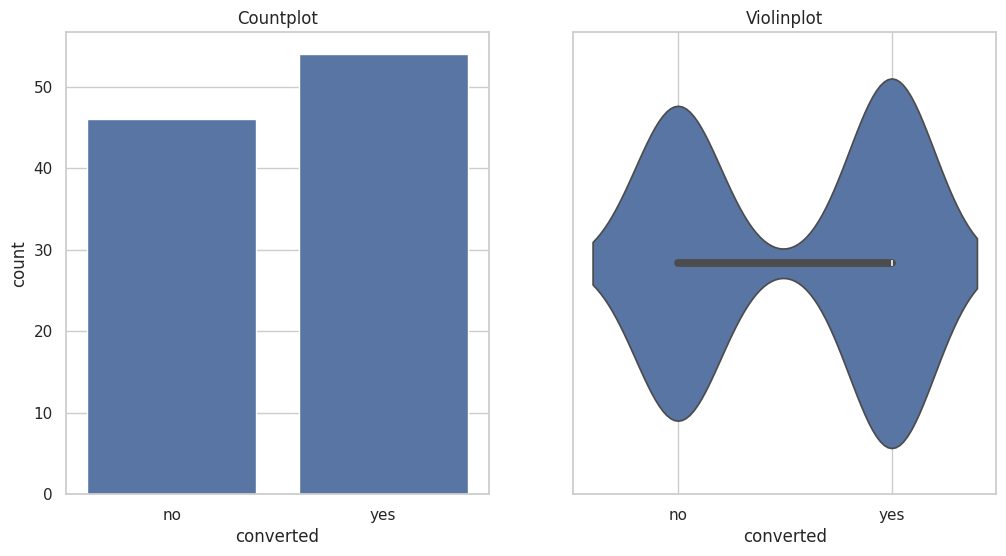

```python
# Create count and violin plots for the 'Converted' variable in the dataset

# Create a figure and set of subplots
fig, axs = plt.subplots(ncols=2, figsize=(12, 6))

E_News_datacopy['converted'].value_counts()
sns.countplot(data=E_News_datacopy,x='converted', ax=axs[0])
axs[0].set_title('Countplot')

sns.violinplot(data=E_News_datacopy,x='converted',ax=axs[1])
axs[1].set_title('Violinplot')
plt.show()
```

- The number of users who later subscribed to E-News Express online news portal is above 50, while about 45-46 users who visited the landing page of the online portal did not subscribe.
- The distribution is skewed towards the left.
- The median of the distribution falls within the users who subscribed to E-News Express new online portal.

**Language Preferred**

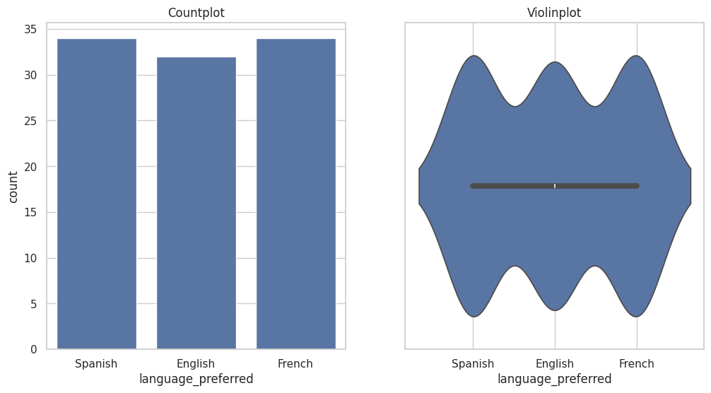

```python
# Create count and violin plots for the 'Language preferred' variable in the dataset

# Create a figure and set of subplots
fig, axs = plt.subplots(ncols=2, figsize=(12, 6))

E_News_datacopy['language_preferred'].value_counts()
sns.countplot(data=E_News_datacopy,x='language_preferred', ax=axs[0])
axs[0].set_title('Countplot')

sns.violinplot(data=E_News_datacopy,x='language_preferred',ax=axs[1])
axs[1].set_title('Violinplot')
plt.show()
```

**Bivariate Analysis**

**Checking relationship between numerical and categorical variables**

**Landing Page vs Time Spent on the page**

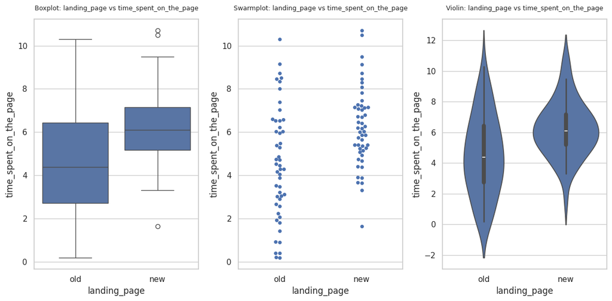

```python
# plotting Landing page vs Time spent on the page using box,swarm, and violin plots

# Create a figure and set of subplots
fig, axs = plt.subplots(ncols=3, figsize=(12, 6))

sns.boxplot(data=E_News_datacopy,x='landing_page',y='time_spent_on_the_page', ax=axs[0])
axs[0].set_title('Boxplot: landing_page vs time_spent_on_the_page',pad=12, fontsize=9)  # Adjust title position and font size

sns.swarmplot(data=E_News_datacopy,x='landing_page',y='time_spent_on_the_page', ax=axs[1])
axs[1].set_title('Swarmplot: landing_page vs time_spent_on_the_page',pad=12, fontsize=9)  # Adjust title position and font size


sns.violinplot(data=E_News_datacopy,x='landing_page',y='time_spent_on_the_page', ax=axs[2])
axs[2].set_title('Violin: landing_page vs time_spent_on_the_page',pad=12, fontsize=9)  # Adjust title position and font size

plt.tight_layout()  # Adjust subplots to prevent overlap
plt.show()
```

- The minimum time and maximum time spent on the the old landing page are a few seconds and above 10 minutes respectively.
- The distribution of users who visited the old landing page is slightly skewed towards the right.
- The median time spent by users that visited the old landing page is about 4.2 minutes.
- There are a few outliers in the distribution of users who visited the new landing page.
- The minimum time and maximum time spent on the the new landing page are about 3 minutes and above 9 minutes respectively.
- The distribution of users who visited the new landing page is slightly skewed towards the right.
- The median time spent by users that visited the new landing page is about 6 minutes or slightly above.
- There is more concentration of users who visited the new landing page at a range of time from 5 to 7 minutes.
- The visitation of users to old landing page is sparsely distributed around time.

**Group vs Time spent on the page**

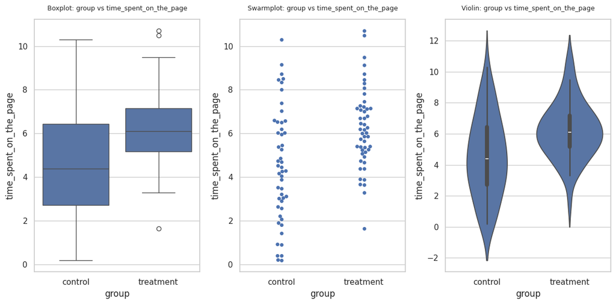

```python
# plotting Group vs Time spent on the page using box,swarm, and violin plots

# Create a figure and set of subplots
fig, axs = plt.subplots(ncols=3, figsize=(12, 6))

sns.boxplot(data=E_News_datacopy,x='group',y='time_spent_on_the_page', ax=axs[0])
axs[0].set_title('Boxplot: group vs time_spent_on_the_page',pad=12, fontsize=9)  # Adjust title position and font size

sns.swarmplot(data=E_News_datacopy,x='group',y='time_spent_on_the_page', ax=axs[1])
axs[1].set_title('Swarmplot: group vs time_spent_on_the_page',pad=12, fontsize=9)  # Adjust title position and font size


sns.violinplot(data=E_News_datacopy,x='group',y='time_spent_on_the_page', ax=axs[2])
axs[2].set_title('Violin: group vs time_spent_on_the_page',pad=12, fontsize=9)  # Adjust title position and font size

plt.tight_layout()  # Adjust subplots to prevent overlap
plt.show()
```

- Control group's lowest time spent on the page is a few seconds and highest time is above 10 minutes.
- Treatment group lowest time spent on the page is about 3 minutes or slightly higher, and highest time is slightly above 9 minutes.
- There are a few outliers between treatment group and time spent on the landing page.
- The distribution of control group in relation to time spent on the page is slightly skewed towards the right while that of treatment group is almost symmetric.
- The median time spent by control group on the page is slightly above 4 minutes while that of treatment group is about 6 minutes or slightly above.
- There is more concentration of treatment group who visited tne new landing page at a range of time from 5 to 7 minutes while that of control group is sparsely distributed around time.

**Conversion status vs Time spent on the page**

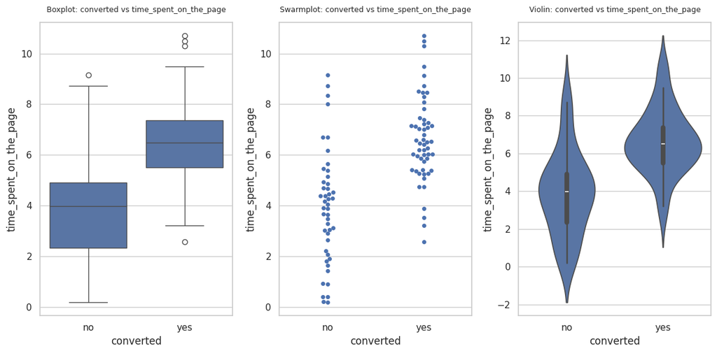

```python
# plotting Converted vs Time spent on the page using box,swarm, and violin plots


# Create a figure and set of subplots
fig, axs = plt.subplots(ncols=3, figsize=(12, 6))

sns.boxplot(data=E_News_datacopy,x='converted',y='time_spent_on_the_page', ax=axs[0])
axs[0].set_title('Boxplot: converted vs time_spent_on_the_page',pad=12, fontsize=9)  # Adjust title position and font size

sns.swarmplot(data=E_News_datacopy,x='converted',y='time_spent_on_the_page', ax=axs[1])
axs[1].set_title('Swarmplot: converted vs time_spent_on_the_page',pad=12, fontsize=9)  # Adjust title position and font size


sns.violinplot(data=E_News_datacopy,x='converted',y='time_spent_on_the_page', ax=axs[2])
axs[2].set_title('Violin: converted vs time_spent_on_the_page',pad=12, fontsize=9)  # Adjust title position and font size

plt.tight_layout()  # Adjust subplots to prevent overlap
plt.show()
```

**Language preferred vs Time spent on the page**

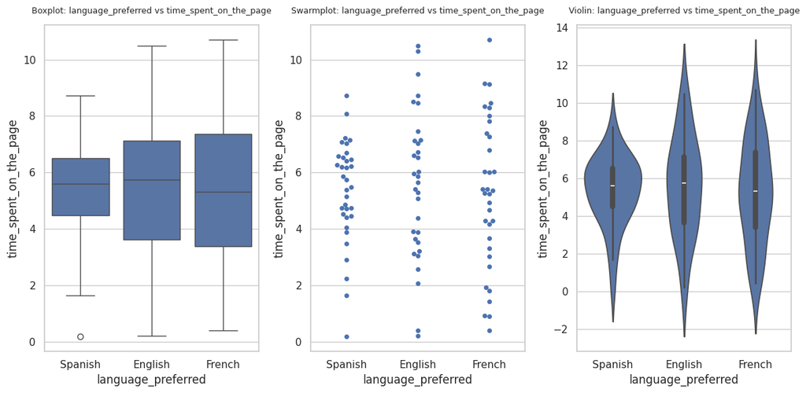

```python
# plotting Language preferred vs Time spent on the page using box,swarm, and violin plots

 # Create a figure and set of subplots
fig, axs = plt.subplots(ncols=3, figsize=(12, 6))

sns.boxplot(data=E_News_datacopy,x='language_preferred',y='time_spent_on_the_page', ax=axs[0])
axs[0].set_title('Boxplot: language_preferred vs time_spent_on_the_page',pad=12, fontsize=9)  # Adjust title position and font size

sns.swarmplot(data=E_News_datacopy,x='language_preferred',y='time_spent_on_the_page', ax=axs[1])
axs[1].set_title('Swarmplot: language_preferred vs time_spent_on_the_page',pad=12, fontsize=9)  # Adjust title position and font size


sns.violinplot(data=E_News_datacopy,x='language_preferred',y='time_spent_on_the_page', ax=axs[2])
axs[2].set_title('Violin: language_preferred vs time_spent_on_the_page',pad=12, fontsize=9)  # Adjust title position and font size

plt.tight_layout()  # Adjust subplots to prevent overlap
plt.show()
```

- Users whose preferred language is Spanish spent minimum of about 1.8 minutes and maximum of almost 9 minutes on the landing page.
- Users whose preferred language is English spent minimum of a few seconds and maximum of about 10.5 minutes on the landing page.
- Users whose preferred language is French spent minimum of slightly above 0.3 minutes and maximum of about 10.7 minutes on the landing page.
- There is a negligible outlier related to users whose preferred language is Spanish.
- Median time for the users whose preferred languages are Spanish, English, and French are about 5.5 , 5.7, and 5.3 minutes respectively.
- Only Spanish language preferred users have the spread of the time spent on page slightly concentrated at 4.3 and between 6.3 to 6,4 minutes. While the time spent on the page by the other users with English and French as preferred languages are sparsely distributed.

**Correlation among variables**

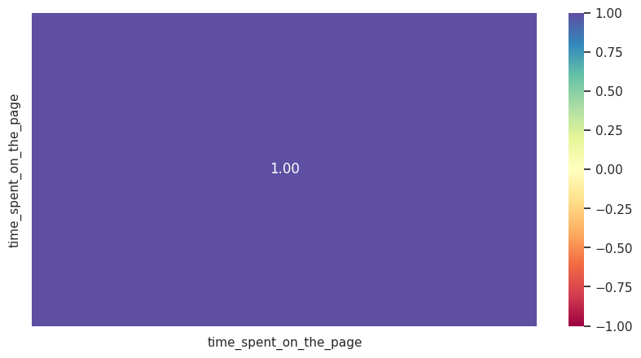

```python
# Plot the heatmap
num_var = ['time_spent_on_the_page', 'language_preferred','group','converted']
plt.figure(figsize=(10, 5))
sns.heatmap(E_News_datacopy[num_var].corr(numeric_only=True), annot=True, vmin=-1, vmax=1, fmt=".2f", cbar=True, cmap="Spectral")
plt.show()
```

**Question 1: Do the users spend more time on the new landing page than the existing landing page?**

**Perform visual Analysis**

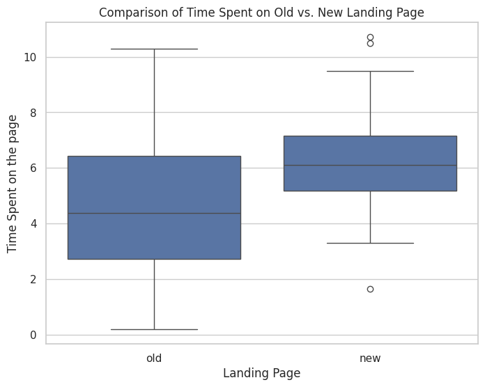

```python
# Create a box plot or violin plot for visual comparison
plt.figure(figsize=(8, 6))
sns.boxplot(x='landing_page', y='time_spent_on_the_page', data=E_News_datacopy)
plt.xlabel('Landing Page')
plt.ylabel('Time Spent on the page')
plt.title('Comparison of Time Spent on Old vs. New Landing Page')
plt.show()
```

- The minimum time and maximum time spent on the the old landing page are a few seconds and above 10 minutes respectively.
- The distribution of users who visited the old landing page is slightly skewed towards the right.
- The median time spent by users that visited the old landing page is about 4.2 minutes.
- There are a few outliers in the distribution of users who visited the new landing page.
- The minimum time and maximum time spent on the new landing page are about 3 minutes and above 9 minutes respectively.
- The distribution of users who visited the new landing page is slightly skewed towards the right.

```python
# Calculate the mean time spent on the page for the old landing page
old_landing_page_mean = np.round(E_News_datacopy[E_News_datacopy['landing_page'] == 'old']['time_spent_on_the_page'].mean(),2)

# Calculate the mean time spent on the page for the new landing page
new_landing_page_mean = np.round(E_News_datacopy[E_News_datacopy['landing_page'] == 'new']['time_spent_on_the_page'].mean(),2)

print("Mean time spent on the page for old landing page:", old_landing_page_mean)
print("Mean time spent on the page for new landing page:", new_landing_page_mean)
```

```
Mean time spent on the page for old landing page: 4.53
Mean time spent on the page for new landing page: 6.22
```

***Plot the distribution plot of time spent on the landing page** *

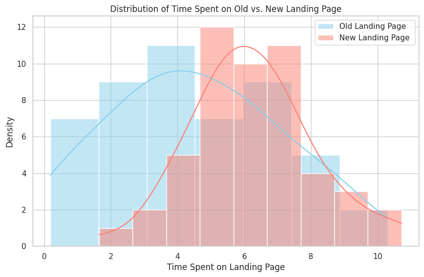

```python
# Set the color palette for the plot
sns.set(style="whitegrid")

# # Create a distribution plot of the time spent on the old landing page and new landing page
plt.figure(figsize=(10, 6))
sns.histplot(data=E_News_datacopy[E_News_datacopy['landing_page'] == 'old'], x='time_spent_on_the_page', kde=True, color='skyblue', label='Old Landing Page' )
sns.histplot(data=E_News_datacopy[E_News_datacopy['landing_page'] == 'new'], x='time_spent_on_the_page', kde=True, color='salmon', label='New Landing Page ')
plt.title('Distribution of Time Spent on Old vs. New Landing Page')
plt.xlabel('Time Spent on Landing Page')
plt.ylabel('Density')
plt.legend()
plt.show()
```

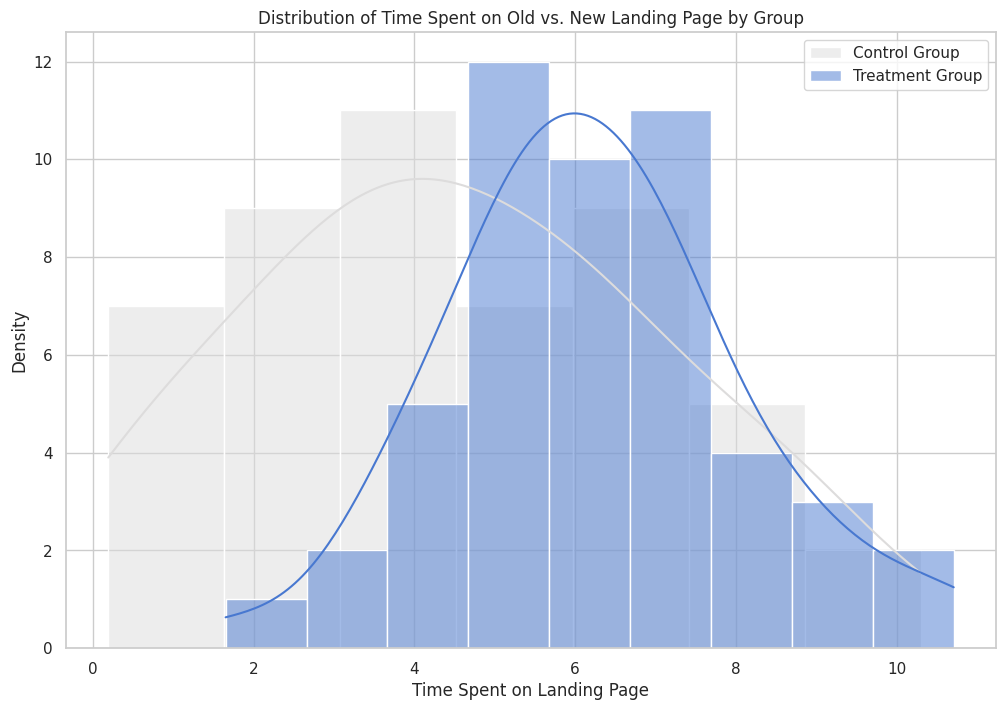

```python
# Set the color palette for the plot
sns.set(style="whitegrid")

# Create a distribution plot of time spent on the old and new landing pages by each group
plt.figure(figsize=(12, 8))
sns.histplot(data=E_News_datacopy[E_News_datacopy['group'] == 'control'], x='time_spent_on_the_page', hue='landing_page', multiple='stack', kde=True, palette='coolwarm', label='Control Group')
sns.histplot(data=E_News_datacopy[E_News_datacopy['group'] == 'treatment'], x='time_spent_on_the_page', hue='landing_page', multiple='stack', kde=True, palette='muted', label='Treatment Group')
plt.title('Distribution of Time Spent on Old vs. New Landing Page by Group')
plt.xlabel('Time Spent on Landing Page')
plt.ylabel('Density')
plt.legend()
plt.show()
```

1.The distribution of the time spent on the old and new pages are slightly skewed to the right.

2.The distribution of the time spent on the old and new pages with respect to control and treatment groups are slightly skewed to the right.

3.This suggest one-tailed test to the right.

**Hypothesis Testing**

**Step 1: Define null and alternative hypotheses**

**Null Hypothesis (H0):**

The null hypothesis states that there is no significant difference in the mean time spent by users on the new landing page compared to the old landing page. Symbolically, it can be represented as:

**H0: μ_new = μ_old**

where μ_new is the population mean time spent on the new landing page and μ_old is the population mean time spent on the old landing page.

**Alternative Hypothesis (Ha):**

The alternative hypothesis suggests that users spend more time on the new landing page than on the old landing page. Symbolically, it can be represented as:

**Ha: μ_new > μ_old**

where μ_new is the population mean time spent on the new landing page and μ_old is the population mean time spent on the old landing page.

Step 2 : **Select the appropriate test**

This is a one-tailed test concerning two population means from two independent populations. The population standard deviations are unknown.

Therefore, the appropriate statistical test is Two-sample independent t-test to compare the mean time spent on the new landing page versus the existing landing page for the two groups.

**Step 3: Set the significance level**

we are asked to perform a statistical analysis (at a significance level of 5%) to determine the effectiveness of the new landing page in gathering new subscribers for the news portal.

**Significance level ( α = 5% or 0.05)**

**Step 4: Collect and prepare data**

Do the following: 1.Subsetted the data to extract the relevant columns for the analysis (e.g., 'time_spent_on_the_page', 'landing_page').

2.Filter the data to separate time spent on the old ('old_page') and new ('new_page') landing pages.

3.Divide the data into time spent on the new landing page and the time spent on the old landing page.

```python
# Subset the DataFrame to include only the specified columns - 'time_spent_on_the_page', 'landing_page'
subset_data = E_News_datacopy[['time_spent_on_the_page', 'landing_page']]

# Display the subsetted data
print(subset_data.head())
```

```
   time_spent_on_the_page landing_page
0                    3.48          old
1                    7.13          new
2                    4.40          new
3                    3.02          old
4                    4.75          new
```

```python
# create subsetted data frame for new landing page users
time_spent_new = E_News_datacopy[E_News_datacopy['landing_page'] == 'new']['time_spent_on_the_page']
# Create a DataFrame for time spent on the new landing page data
time_spent_new_table = pd.DataFrame(time_spent_new)

# create subsetted data frame for old landing page users
time_spent_old = E_News_datacopy[E_News_datacopy['landing_page'] == 'old']['time_spent_on_the_page']
# Create a DataFrame for time spent on the old landing page data
time_spent_old_table = pd.DataFrame(time_spent_old)

# Display the tables
print('The time spent on the new landing page is\n', time_spent_new_table)
print('The time spent on the old landing page is\n',time_spent_old_table)
```

```
The time spent on the new landing page is
     time_spent_on_the_page
1                     7.13
2                     4.40
4                     4.75
6                     5.25
8                    10.71
12                    5.86
13                    6.03
15                    6.27
16                    8.73
22                    3.65
23                    7.02
24                    6.18
25                    4.39
```

[output cut: 89 more lines]

```python
# Calculate the standard deviations of time spent on both the new and old landing pages and decide if their standard deviations are equal or not
print('The sample standard deviation of the time spent on the new page is:', round(time_spent_new.std(),2))
print('The sample standard deviation of the time spent on the old page is:', round(time_spent_old.std(),2))
```

```
The sample standard deviation of the time spent on the new page is: 1.82
The sample standard deviation of the time spent on the old page is: 2.58
```

***From above, we can conclude that the standard deviation of the time spent on the new page is not equal(less than) to the standard deviation of the time spent on the new page.** *

Let's test whether the T-test assumptions of Central Limit Theorem are satisfied or not

1.Continuous data - Yes, the time spent on landing page is measured on a continuous scale.

2.Normally distributed population and Sample size is 100(> 30 )- Yes, it is assumed that the population is normal and the sample size is 100 which is divided into two groups ,each with 50 users.

3.Observations are from a simple random sample - Yes, we are informed that the collected sample a simple random sample.

4.Population standard deviation is known - No

**Step 5: Calculate the p-value**

**Since the standard deviation of the Time spent on the new landing page is less than the standard deviation of the Time spent on the old landing page, the 2-sample independent t-test will assume unequal variances.**

```python
# Extract data for the two groups (new landing page and existing landing page)
time_spent_new = E_News_datacopy[E_News_datacopy['landing_page'] == 'new']['time_spent_on_the_page']
time_spent_old = E_News_datacopy[E_News_datacopy['landing_page'] == 'old']['time_spent_on_the_page']

# Perform two-sample t-test assuming unequal variances
t_statistic, p_value = stats.ttest_ind(time_spent_new, time_spent_old, equal_var=False, alternative = 'greater')

# Set the significance level (alpha)
alpha = 0.05

# Print the results of the t-test
if p_value < alpha:
    print("Reject the null hypothesis: There is a statistically significant difference in the mean time spent on the two landing pages.")
else:
    print("Fail to reject the null hypothesis: There is no statistically significant difference in the mean time spent on the two landing pages.")

# Print the t-statistic and p-value for reference
print(f"T-Statistic: {t_statistic}")
print(f"P-Value: {p_value}")
```

```
Reject the null hypothesis: There is a statistically significant difference in the mean time spent on the two landing pages.
T-Statistic: 3.7867702694199856
P-Value: 0.0001392381225166549
```

**Calculating Levene -statistic and p-value using Levene test**

```python
# Perform Levene's Test to check for equal variances
statistic, p_value_levene = stats.levene(time_spent_new, time_spent_old)

# Set the significance level (alpha)
alpha = 0.05

# Print the results of Levene's Test
if p_value_levene < alpha:
    print("Reject the null hypothesis: Variances are not equal.")
else:
    print("Fail to reject the null hypothesis: Variances are equal.")

# Print the test statistic and p-value
print(f"Levene's Test - Statistic: {statistic}")
print(f"Levene's Test - P-Value: {p_value_levene}")
```

```
Reject the null hypothesis: Variances are not equal.
Levene's Test - Statistic: 7.113724153407544
Levene's Test - P-Value: 0.008950671168914447
```

**Step 6: Compare the p-value with 𝛼**

```python
# print the conclusion based on p-value
if p_value < 0.05:
    print(f'As the p-value {p_value} is less than the level of significance, we reject the null hypothesis.')
else:
    print(f'As the p-value {p_value} is greater than the level of significance, we fail to reject the null hypothesis.')
```

```
As the p-value 0.0001392381225166549 is less than the level of significance, we reject the null hypothesis.
```

```python
 # Print the conclusion based on Levene's Test
if p_value_levene < alpha:
    print("Reject the null hypothesis: Variances are not equal.")
else:
    print("Fail to reject the null hypothesis: Variances are equal.")
```

```
Reject the null hypothesis: Variances are not equal.
```

**Step 7: Draw Conclusion**

Since p-value (= 0.0001392381225166549 ) is less than alpha (= 0.05), we do have sufficient evidence to accept that users spend more time on the new landing page than on the old landing page.

***Plotting t-stat distribution** *

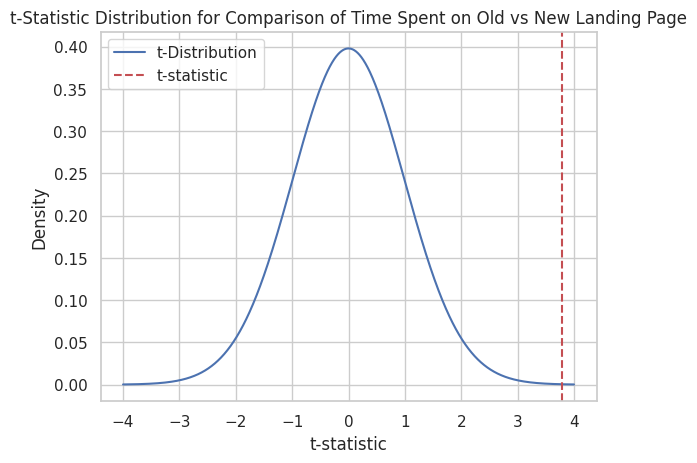

```python
# Import required function
from scipy.stats import t

# Set sample size of both old and new landing pages
sample_size_old_page = 50
sample_size_new_page = 50

# Time spent data for old and new landing pages
# create subsetted data frame for new landing page users and old landing page users
time_spent_new = E_News_datacopy[E_News_datacopy['landing_page'] == 'new']['time_spent_on_the_page']
time_spent_old = E_News_datacopy[E_News_datacopy['landing_page'] == 'old']['time_spent_on_the_page']

# Degrees of freedom (assuming equal sample sizes and variances)
df = sample_size_old_page + sample_size_new_page - 2

# Set the t-statistic value
t_stat = 3.7867702694199856

# Generate x values for the t-statistic distribution plot
x = np.linspace(-4, 4, 1000)

# Calculate the t-distribution PDF values
pdf_vals = t.pdf(x, df)

# Plot the t-distribution curve
plt.plot(x, pdf_vals, label='t-Distribution', color='b')

# Find the maximum PDF value near the t-statistic
max_pdf_val = pdf_vals[np.abs(x - t_stat).argmin()]

# Highlight the t-statistic value with a vertical line
plt.axvline(x=t_stat, color='r', linestyle='--', label='t-statistic')

# Set titles and labels
plt.title('t-Statistic Distribution for Comparison of Time Spent on Old vs New Landing Page')
plt.xlabel('t-statistic')
plt.ylabel('Density')
plt.legend()

# Show the plot
plt.show()
```

- A t-stat of 3.79 indicates that the value is approximately 3.79

standard deviations away from the mean in a t-distribution (considering the degrees of freedom involved).

- A t-stat of 3.79 suggests a significant deviation from the mean in the t-distribution, potentially indicating a strong effect or result in the data.
- Such a high t-stat may indicate the presence of outliers or extreme values in the data being analyzed, impacting the distribution of the t-statistic.

**Question 2. Is the conversion rate (the proportion of users who visit the landing page and get converted) for the new page greater than the conversion rate for the old page?**

**Perform visual analysis**

```
The proportion of conversion in old landing page is 0.42
The proportion of conversion in new landing page is 0.66
```

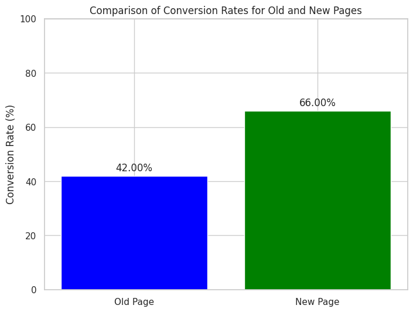

```python
# Calculate the count of users who were 'converted' with 'yes' from the old landing page
converted_old_landing_page_count = E_News_datacopy[(E_News_datacopy['landing_page'] == 'old') & (E_News_datacopy['converted'] == 'yes')].shape[0]

# Calculate the count of users who were 'converted' with 'yes' from the new landing page
converted_new_landing_page_count = E_News_datacopy[(E_News_datacopy['landing_page'] == 'new') & (E_News_datacopy['converted'] == 'yes')].shape[0]

# Filter the dataset for converted subscribers in new and old landing pages
# Calculate conversion rates
total_users_on_old_page =50
total_users_on_new_page =50
conversion_rate_old_page = (converted_old_landing_page_count / total_users_on_old_page)
conversion_rate_new_page = (converted_new_landing_page_count / total_users_on_new_page)

conversion_rate_old_page_percentage = conversion_rate_old_page * 100
conversion_rate_new_page_percentage = conversion_rate_new_page * 100

# Create a bar chart to compare conversion rates
conversion_rates = [conversion_rate_old_page, conversion_rate_new_page]
conversion_rates_percentage = [conversion_rate_old_page_percentage, conversion_rate_new_page_percentage]
pages = ['Old Page', 'New Page']


print('The proportion of conversion in old landing page is',(conversion_rate_old_page*50)/50 )
print('The proportion of conversion in new landing page is',(conversion_rate_new_page*50)/50 )


plt.figure(figsize=(8, 6))

plt.bar(pages, conversion_rates_percentage, color=['blue', 'green'])
plt.ylabel('Conversion Rate (%)')
plt.title('Comparison of Conversion Rates for Old and New Pages')
plt.ylim(0, 100)

# Add the exact conversion rate values on top of the bars
for i, value in enumerate(conversion_rates_percentage):
    plt.text(i, value + 1, f"{value:.2f}%", ha='center', va='bottom')

plt.show()
```

- The proportion of users who subscribed to E-News online portal after visited old landing page is 42%.
- The proportion of users who subscribed to E-News online portal after visited new landing page is 66%.

**Step 1: Define Null and Alternative Hypotheses**

Null Hypothesis: The conversion rate for the new landing page is less than or equal to the conversion rate for the old landing page. Mathematically, this can be represented as:

**H0: P_new <= P_old**

(where P_new is the conversion rate for the new landing page and P_old is the conversion rate for the old landing page)

**Alternative Hypothesis (Ha):**

Alternative Hypothesis: The conversion rate for the new landing page is greater than the conversion rate for the old landing page. Mathematically, this can be represented as:

**Ha: P_new > P_old**

(where P_new is the conversion rate for the new landing page and P_old is the conversion rate for the old landing page)

**Step 2: Select the Appropriate test**

Two -sample proportions z- test is appropriate. There are two independent samples that are discrete and randomly picked from the population. The two samples have different proportion of users that subscribed to either old or new landing page.

There are two outcomes: converted users or non-converted users.

There is approximately Normally Distributed Differences of Proportions if : nP_new>=10 , nP_old>= 10, n(1-P_new)>=10, and n(1-P_old)>=10,  
n = 50, P_new(proportion of conversion in new landing page) = 33/50, P_old = (proportion of conversion in old landing page) = 21/50

nP_new = 50* 33/50=33>10, nP_old= 50* 21/50> 10 n(1-P_new) = 50((50-33)/50 )= 17>10 n(1-P_old) = 50((50-21)/50) = 29>10

**Step 3: Set the significance level**

we are asked to perform a statistical analysis (at a significance level of 5%) to determine the effectiveness of the new landing page in gathering new subscribers for the news portal.

**Significance level ( α = 5% or 0.05)**

**Step 4: Collect and prepare data**

Do the following: 1.Subsetted the data to extract the relevant columns for the analysis ( converted' and 'landing page').

2.Filter the data to separate how many users were converted on the old ('old_page') and new ('new_page') landing pages. **This is already done under visual analysis.**

3.Divide the data into converted on the new landing page and the convereted on the old landing page.

```python
# Subset the DataFrame to include only the specified columns - 'converted', 'landing_page'
subset_data = E_News_datacopy[['converted', 'landing_page']]

# Display the subsetted data
print(subset_data.head())
```

```
  converted landing_page
0        no          old
1       yes          new
2        no          new
3        no          old
4       yes          new
```

```python
# calculate the number of converted users in the treatment group
new_converted = E_News_datacopy[E_News_datacopy['group'] == 'treatment']['converted'].value_counts()['yes']
# calculate the number of converted users in the control group
old_converted = E_News_datacopy[E_News_datacopy['group'] == 'control']['converted'].value_counts()['yes'] # complete your code here

n_control = E_News_datacopy.group.value_counts()['control'] # total number of users in the control group
n_treatment = E_News_datacopy.group.value_counts()['treatment'] # total number of users in the treatment group

print('The numbers of users served the new and old pages are {0} and {1} respectively'.format(n_control, n_treatment ))
```

```
The numbers of users served the new and old pages are 50 and 50 respectively
```

```python
# Calculate the count of users who were 'converted' with 'yes' from the old landing page
converted_old_landing_page_count = E_News_datacopy[(E_News_datacopy['landing_page'] == 'old') & (E_News_datacopy['converted'] == 'yes')].shape[0]

# Calculate the count of users who were 'converted' with 'yes' from the new landing page
converted_new_landing_page_count = E_News_datacopy[(E_News_datacopy['landing_page'] == 'new') & (E_News_datacopy['converted'] == 'yes')].shape[0]

# Display the count of users who were 'converted' with 'yes' from the old and new landing pages
print(f"Count of users converted with 'yes' from the old landing page: {converted_old_landing_page_count}")
print(f"Count of users converted with 'yes' from the new landing page: {converted_new_landing_page_count}")
```

```
Count of users converted with 'yes' from the old landing page: 21
Count of users converted with 'yes' from the new landing page: 33
```

Test of Assumptions of Cental Limit Theorem

Random Sampling: Both samples are selected randomly from their respective populations.

Independent Samples: The samples should be independent of each other.

Sample Size: Each sample size > 30 which make them large enough.

Approximately Normal Distribution: The sampling distribution of the difference in sample proportions is approximately normally distributed. We asume this before each samlpe size is large enough.

**Step 5: Calculate the p-value**

```python
# Import required function
from statsmodels.stats.proportion import proportions_ztest

# Define old and new landing pages sizes
n_old = 50
n_new =50

# Define the number of users converted after visited old and new landing pages
converted_old_landing_page_count = 21
converted_new_landing_page_count = 33

# Set the count of converted users on new landing page and old landing page
converted_count = np.array([converted_old_landing_page_count, converted_new_landing_page_count])

# Set the sample size
nobs= np.array([n_old, n_new])

# Perform two-sample proportion z-test
z_stat, p_val = proportions_ztest(converted_count, nobs)

if p_val < 0.05:
    print("Reject the null hypothesis. The conversion rate of users who visited the new landing page is higher than that of the users who visited the old landing page.")
else:
    print("Accept the null hypothesis. The conversion rate of users who visited the new landing page is not higher than that of the users who visited the old landing page.")

 # Print the t-statistic and p-value for reference
print(f"Z-Statistic: {z_stat}")
print(f"P-Value: {p_value}")
```

[output not shown]

**Step 6: Compare the p-value with α**

```python
# print the conclusion based on p-value
if p_value < 0.05:
    print(f'As the p-value {p_value} is less than the level of significance, we reject the null hypothesis.')
else:
    print(f'As the p-value {p_value} is greater than the level of significance, we fail to reject the null hypothesis.')
```

[output not shown]

**Step 7: Draw Conclusion**

**Plot Z-statistic Distribution**

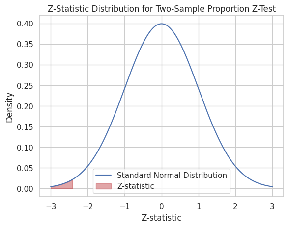

```python
# Z-statistic value
z_stat = -2.4077170617153842

# Assuming a standard normal distribution with mean (mu) = 0 and standard deviation (sigma) = 1
mu = 0
sigma = 1

# Generate x values for the Z-statistic distribution plot
x = np.linspace(-3, 3, 1000)

# Plot the standard normal distribution curve
plt.plot(x, norm.pdf(x, mu, sigma), label='Standard Normal Distribution', color='b')

# Highlight the Z-statistic value on the distribution
plt.fill_between(x, 0, norm.pdf(x, mu, sigma), where=(x <= z_stat), color='r', alpha=0.5, label='Z-statistic')

# Set titles and labels
plt.title('Z-Statistic Distribution for Two-Sample Proportion Z-Test')
plt.xlabel('Z-statistic')
plt.ylabel('Density')
plt.legend()

# Show the plot
plt.show()
```

A Z-stat of -2.41 indicates that the value is approximately 2.41 standard deviations below the mean in a standard normal distribution.

A Z-stat of -2.41 suggests that the observation is at an extreme point far from the mean, which might be considered statistically significant, especially if it falls outside the typical range in a standard normal distribution.

Such a low Z-stat indicates an outlier or an observation significantly different from the normal values in the distribution.

**Question 3: Does the converted status depend on the preferred language?**

**Perform Visual Analysis**

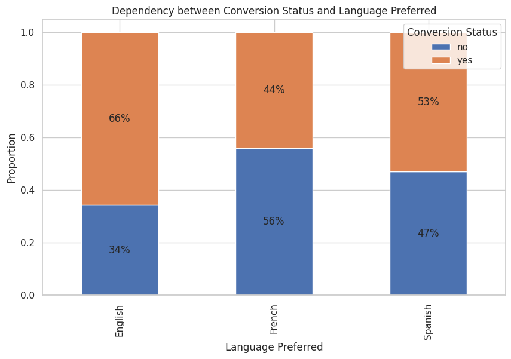

```python
# Assuming 'converted' and 'language_preferred' columns represent conversion status and language preference
# Create a contingency table and normalize by row to get proportions
contingency_table = pd.crosstab(E_News_datacopy['language_preferred'], E_News_datacopy['converted'], normalize='index')

# Plotting the stacked bar plot with percentage proportions
ax = contingency_table.plot(kind="bar", figsize=(10, 6), stacked=True)
plt.title("Dependency between Conversion Status and Language Preferred")
plt.xlabel("Language Preferred")
plt.ylabel("Proportion")

# Adding percentage labels to the plot
for p in ax.patches:
    width, height = p.get_width(), p.get_height()
    x, y = p.get_xy()
    ax.annotate(f'{height:.0%}', (x + width/2, y + height/2), ha='center', va='center')

plt.legend(title='Conversion Status')
plt.show()
```

The proportion of English preferred users that visited the landing pages and became subscribers is 66% while 34% did not subscribe.

The proportion of French preferred users that visited the landing pages and became subscribers is 44% while 56% did not subscribe.

The proportion of Spanish preferred users that visited the landing pages and became subscribers is 53% while 47% did not subscribe.

```python
 # Select the columns for conversion status and language preferred
columns_of_interest = ['converted', 'language_preferred']
df1 = E_News_datacopy[columns_of_interest].copy()

# Group by language preferred and summarize conversion status
conversion_status_summary = df1.groupby('language_preferred')['converted'].value_counts().unstack().fillna(0)

# Display the DataFrame showing the conversion status for each language preferred
print(conversion_status_summary)
```

```
converted           no  yes
language_preferred
English             11   21
French              19   15
Spanish             16   18
```

**Step 1 :Define the null and alternative hypothesis**

**Null Hypothesis (H0): The conversion status of users does not depend on their preferred language.**

**Alternative Hypothesis (Ha): The conversion status of users depends on their preferred language.**

**Step 2: Select Appropriate test**

**The Chi-square test of independence** is selected to determine if there is a significant association between the conversion status and preferred language.

Both conversion status and preferred language are categorical variables, and Chi-square test is specifically designed to analyze the association between two categorical variables.

The Chi-square test allows us to compare the expected frequencies (if the variables were independent) with the observed frequencies in the data.

Chi-square test is good to analyze association between nominal variable ( language preferred) and a variable with a binary outcome( conversion status: 'converted', and 'not converted'.

**Step 3: Set the significance level**

we are asked to perform a statistical analysis (at a significance level of 5%) to determine if converted status depend on the preferred language.

**Significance level ( α = 5% or 0.05)**

**Step 4: Collect and prepare data**

```python
# Create a Dataframeshowing the conversion status for each language preferred
# Select the columns for conversion status and language preferred
columns_of_interest = ['converted', 'language_preferred']
df1 = E_News_datacopy[columns_of_interest].copy()

# Group by language preferred and summarize conversion status
conversion_status_summary = df1.groupby('language_preferred')['converted'].value_counts().unstack().fillna(0)

df1.head()
```

|  | converted | language_preferred |
| --- | --- | --- |
| 0 | no | Spanish |
| 1 | yes | English |
| 2 | no | Spanish |
| 3 | no | French |
| 4 | yes | Spanish |

```python
# Select the columns for conversion status and language preferred
columns_of_interest = ['converted', 'language_preferred']
df1 = E_News_datacopy[columns_of_interest].copy()

# Group by language preferred and summarize conversion status
conversion_status_summary = df1.groupby('language_preferred')['converted'].value_counts().unstack().fillna(0)

# Display the DataFrame showing the conversion status for each language preferred
print(conversion_status_summary)
```

```
converted           no  yes
language_preferred
English             11   21
French              19   15
Spanish             16   18
```

```python
 # Create a contingency table showing the distribution of the two categorical variables
contingency_table = pd.crosstab(df1['converted'], df1[ 'language_preferred'])

contingency_table
```

| language_preferred converted | English | French | Spanish |
| --- | --- | --- | --- |
| no | 11 | 19 | 16 |
| yes | 21 | 15 | 18 |

Test of Assumptions of Central Limit Theorem

Random Sampling: The data are obtained through a random sampling process.

The Sample Size is large enough: Each cell in the contingency table (used for chi-square analysis) has a frequency more than 5.

The observations in the data are independent of each other.

The variables being analyzed are both categorical.

**Step 5: Calculate p-value**

```python
# Import required function
from scipy.stats import chi2_contingency

# Calculate the p-value using the chi2_contingency function
chi2_stat, p_value, dof, exp_freq = chi2_contingency(contingency_table)

# Print the Chi-square statistic and p-value
print('Chi-square Statistic:', chi2_stat)
print('P-value:', p_value)
```

```
Chi-square Statistic: 3.0930306905370837
P-value: 0.21298887487543447
```

**Step 6 :Compare the p-value with 𝛼**

```python
# print the conclusion based on p-value
if p_value < 0.05:
    print(f'As the p-value {p_value} is less than the level of significance, we reject the null hypothesis.')
else:
    print(f'As the p-value {p_value} is greater than the level of significance, we fail to reject the null hypothesis.')
```

```
As the p-value 0.21298887487543447 is greater than the level of significance, we fail to reject the null hypothesis.
```

**Step 7: Draw inference**

Since p-value (= 0.21298887487543447 ) is greater than alpha (= 0.05), we do not have sufficient evidence to reject the statement that the conversion status of users does not depend on their preferred language.

**Plot Chi2 - statistic distribution**

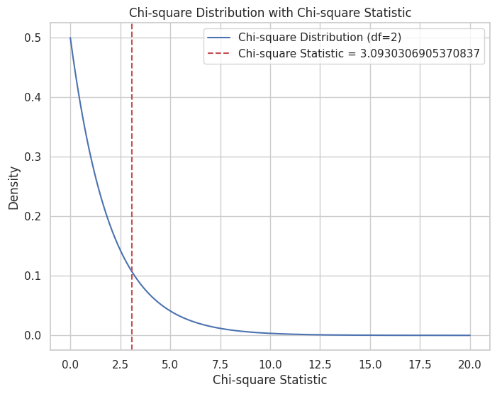

```python
# Import required function
from scipy.stats import chi2

# Degrees of freedom for the Chi-square distribution
number_of_rows = 2
number_of_columns = 3
df =(number_of_rows  - 1) * (number_of_columns - 1)
df = 1 * 2
df = 2

# Calculate the Chi-square statistic
chi_stat = 3.0930306905370837    # Insert the actual calculated Chi-square statistic here


# Generate x values for the Chi-square distribution plot
x = np.linspace(0, 20, 1000)  # Adjust the range of x values based on the distribution

# Calculate the Chi-square distribution PDF values
pdf_vals = chi2.pdf(x, df)

# Plot the Chi-square distribution curve
plt.figure(figsize=(8, 6))
plt.plot(x, pdf_vals, label=f'Chi-square Distribution (df={df})', color='b')

# Plot the Chi-square statistic with a vertical line on the plot
plt.axvline(x=chi_stat, color='r', linestyle='--', label=f'Chi-square Statistic = {chi_stat}')

# Set titles and labels
plt.title('Chi-square Distribution with Chi-square Statistic')
plt.xlabel('Chi-square Statistic')
plt.ylabel('Density')
plt.legend()

# Show the plot
plt.grid(True)
plt.show()
```

A Chi-square statistic of 3.09 indicates the magnitude of the discrepancy between observed and expected frequencies in the data based on the Chi-square test.

The Chi-square statistic is often used to assess the goodness of fit of a model to the observed data. A value of 3.09 may indicate a reasonable fit, but further analysis is needed.

**Question 4: Is the time spent on the new page same for the different language users?**

**Perform Visual Analysis**

```python
# Create a dataframe for users who visited new landing page
df_new = E_News_datacopy[E_News_datacopy['landing_page'] == 'new']
df_new. head()
```

|  | group | landing_page | time_spent_on_the_page | converted | language_preferred |
| --- | --- | --- | --- | --- | --- |
| 1 | treatment | new | 7.13 | yes | English |
| 2 | treatment | new | 4.40 | no | Spanish |
| 4 | treatment | new | 4.75 | yes | Spanish |
| 6 | treatment | new | 5.25 | yes | French |
| 8 | treatment | new | 10.71 | yes | French |

```python
# Filter the dataset to select only the 'time_spent_on_the_page' and 'language_preferred' columns
filtered_data = E_News_datacopy[['time_spent_on_the_page', 'language_preferred']]

# Display the filtered dataset, the first- five rows
filtered_data.head()
```

|  | time_spent_on_the_page | language_preferred |
| --- | --- | --- |
| 0 | 3.48 | Spanish |
| 1 | 7.13 | English |
| 2 | 4.40 | Spanish |
| 3 | 3.02 | French |
| 4 | 4.75 | Spanish |

```python
# Display the filtered dataset, the last five rows
filtered_data.tail()
```

|  | time_spent_on_the_page | language_preferred |
| --- | --- | --- |
| 95 | 5.15 | Spanish |
| 96 | 6.52 | English |
| 97 | 7.07 | Spanish |
| 98 | 6.20 | Spanish |
| 99 | 5.86 | English |

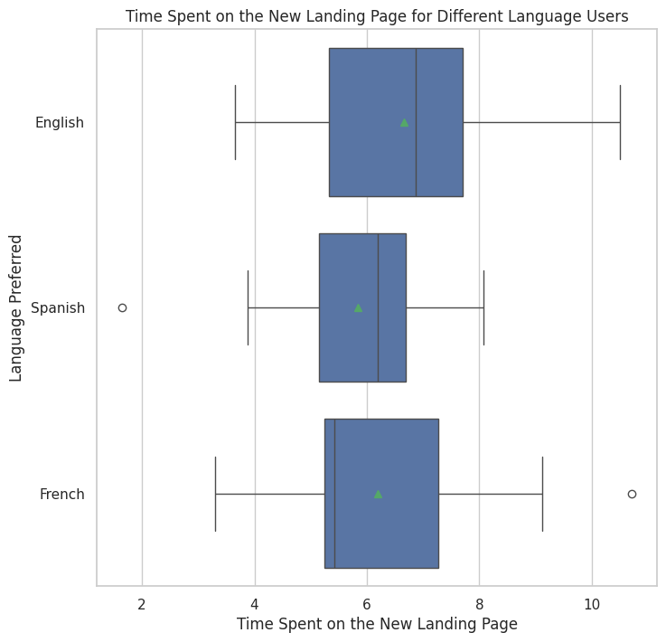

```python
# Plot the time spent on the new page for different language users
plt.figure(figsize=(8,8))
sns.boxplot(x = 'time_spent_on_the_page', y = 'language_preferred', showmeans = True, data = df_new)

plt.title('Time Spent on the New Landing Page for Different Language Users')
plt.xlabel('Time Spent on the New Landing Page')
plt.ylabel('Language Preferred')

# Display the plot
plt.show()
```

**Observations**

The Spanish preferred users who visited the new landing page spent minimum of 3.9 minutes, maximum of 8.1 minutes, and median time of 6.2 minutes. Its distribution is left skewed.

The French preferred users who visited the new landing page spent minimum of between 3.2-3.3 minutes, maximum of slightly above 9 minutes, and median time of about 5.3 minutes. Its distribution is right skewed. It has also a minimal outlier(s).

```python
# Calculate the mean time spent on the new landing page for different language users
mean_time_spent = df_new.groupby(['language_preferred'])['time_spent_on_the_page'].mean()

# Display the mean time spent on the new page for different language users
print(mean_time_spent)
```

```
language_preferred
English    6.663750
French     6.196471
Spanish    5.835294
Name: time_spent_on_the_page, dtype: float64
```

**Step 1 : Define the null and alternative hypotheses**

**Null Hypothesis (H0):**

The null hypothesis states that there is no significant difference in the time spent on the new page across different language users.

**H0: The mean time spent on the new page is the same for all language users.**

**Alternative Hypothesis (Ha):**

The alternative hypothesis represents the assertion that there is a significant difference in the time spent on the new page among different language users.

H**a: The mean time spent on the new page varies across different language users.**

In statistical terms:

***H0: μ1 = μ2 = μ3 = ... = μn** * (Mean time spent on the new page is the same for all language users)

**Ha: At least one pair of means is significantly different from each other.**

**Step 2: Select Appropriate test**

1.Analysis of Variance (ANOVA) test will be used to compare the mean time spent on the new landing page among different language user groups.

2.ANOVA (Analysis of Variance) test is use for comparing the means of multiple groups.

3.The obersavations with each group are independent of each other.

4.Data points should be collected using random sampling techniques to ensure that the sample is representative of the population.

6.We shall assume that variances of the different groups should be roughly equal.

**Step 3: Set the significance level**

We are asked to perform a statistical analysis (at a significance level of 5%) to determine if the time spent on the new page same for the different language users.

**Significance level ( α = 5% or 0.05)**

**Step 4 : Collect and prepare data**

```python
# create a subsetted data frame of the time spent on the new page by English language users
Englang_time_spent = df_new[df_new['language_preferred']=="English"]['time_spent_on_the_page']
title = 'The time spent on the new page by English language users is \n'
print(title)
print(Englang_time_spent.head())

print("\n") # Add an empty line between the outputs

# create subsetted data frames of the time spent on the new page by French language users
Frenlang_time_spent = df_new[df_new['language_preferred']=='French']['time_spent_on_the_page']
title = 'The time spent on the new page by French language users is \n '
print(title)
print(Frenlang_time_spent.head())

print("\n") # Add an empty line between the outputs

# create subsetted data frames of the time spent on the new page by Spanish language users
Spanlang_time_spent = df_new[df_new['language_preferred']=='Spanish']['time_spent_on_the_page']
title = 'The time spent on the new page by Spanish language users is \n '
print(title)
print(Spanlang_time_spent.head())
```

```
The time spent on the new page by English language users is

1     7.13
16    8.73
22    3.65
23    7.02
25    4.39
Name: time_spent_on_the_page, dtype: float64


The time spent on the new page by French language users is

6      5.25
8     10.71
13     6.03
28     7.81
46     5.37
Name: time_spent_on_the_page, dtype: float64


The time spent on the new page by Spanish language users is

2     4.40
4     4.75
12    5.86
15    6.27
24    6.18
Name: time_spent_on_the_page, dtype: float64
```

**Step 5: Calculate the p-value**

```python
# Import required function
from scipy.stats import f_oneway

# Perform ANOVA test
f_statistic, p_value = f_oneway(Englang_time_spent, Frenlang_time_spent, Spanlang_time_spent)

print("ANOVA Statistic:", f_statistic)
print("P-value:", p_value)
```

```
ANOVA Statistic: 0.8543992770006822
P-value: 0.43204138694325955
```

**Step 6 : Compare p-value with α**

```python
# print the conclusion based on p-value
if p_value < 0.05:
    print(f'As the p-value {p_value} is less than the level of significance, we reject the null hypothesis.')
else:
    print(f'As the p-value {p_value} is greater than the level of significance, we fail to reject the null hypothesis.')
```

```
As the p-value 0.43204138694325955 is greater than the level of significance, we fail to reject the null hypothesis.
```

**Step 7 : Draw Inference**

Since p-value (= 0.43204138694325955 ) is greater than alpha (= 0.05), we do not have sufficient evidence to reject the null hypothesis that there is no significant difference in the time spent on the new landing page across different language users.

**Plot the Anova Statistic Distribution**

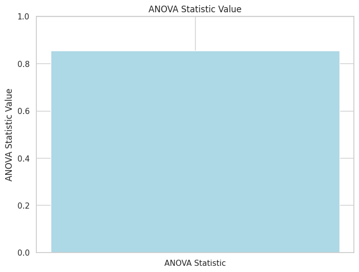

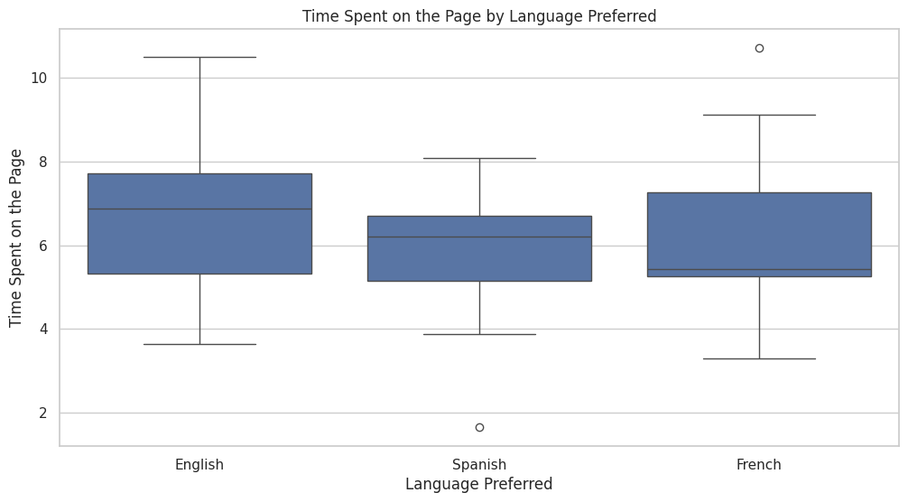

```python
# Plot ANOVA Statistic for better visualization of the calculations
# ANOVA Statistic Value
ANOVA_statistic = 0.8543992770006822

# Create a bar plot for ANOVA Statistic
plt.figure(figsize=(8, 6))
plt.bar(["ANOVA Statistic"], [ANOVA_statistic], color='lightblue')
plt.ylabel('ANOVA Statistic Value')
plt.title('ANOVA Statistic Value')
plt.ylim(0, 1)  # Set y-axis limits based on the ANOVA value
plt.show()

# Plot between language_preferred and time_spent_on_the_page
plt.figure(figsize=(12, 6))
sns.boxplot(x='language_preferred', y='time_spent_on_the_page', data=df_new)
plt.title('Time Spent on the Page by Language Preferred')
plt.xlabel('Language Preferred')
plt.ylabel('Time Spent on the Page')
plt.show()
```

1.The ANOVA statistic gives a square-shape plot.

5.This means that people who prefer different languages do not spend significantly different amounts of time on the page.

Based on these results, we can conclude that language preference does not have a significant impact on the amount of time spent on the page.

**Conclusions and Business Recomendations.**

Based on the analysis and results obtained from the statistical tests and visualizations in the scenario provided, some of the conclusions and business recommendations are:

**Coclusions**

**Time Spent on Landing Pages:**

i. Users spend more time on the new landing page compared to the old landing page.

ii.This indicates that the redesign and content improvements on the new landing page have successfully engaged users for a longer duration.

**Conversion Rate:**

i.The conversion rate for the new landing page is greater than the conversion rate for the old landing page.

ii.This suggests that the changes made to the landing page have positively impacted user conversions and engagement.

**Effect of Preferred Language on Conversion:**

i.The conversion status does not significantly depend on the preferred language of users.

ii.This implies that the language preference of users does not play a significant role in their decision to subscribe to the news portal.

**Time Spent on New Page Across Languages:**

i.The time spent on the new page is fairly consistent across different language preferences.

ii.Users of various language preferences show similar engagement levels with the new landing page.

**General Observations:**

i.The dataset has been thoroughly analyzed for various aspects such as time spent on pages, user conversions, group distributions, and language preferences.

ii.The statistical summaries and visual analyses provide a clear understanding of user behavior and preferences on the landing pages.

**Business Recommendations:**

**1.Continue to Monitor and Optimize New Landing Page:**

Given the positive results on user engagement and conversion rates with the new landing page, continue to monitor user interactions and further optimize the page for enhanced user experience.

**2.Personalization Based on Language Preferences:**

While language preference does not seem to directly impact conversion rates, consider personalized content or recommendations based on the preferred language to improve user experience.

**3.Further A/B Testing and Iterations:**

Conduct further A/B testing with variations on the new landing page to identify the most effective design elements and content that drive user engagement and conversions.

**4.Segmentation and Targeting:**

Analyze user behavior further to segment users based on their interactions with the landing pages and personalize content or offers to specific user segments for improved conversion rates.

**5.Engage Users with Interactive Elements:**

Given the advantages of e-news portals to offer multimedia content, consider incorporating more interactive elements like videos, graphics, and audio to enhance user engagement further.

**6.Regular Data Analysis and Insights:**

Maintain regular data analysis practices to gain insights into user behavior, preferences, and trends, enabling data-driven decision-making to improve business outcomes.